# Praca domowa 1

Dorota Łępicka

Celem naszej pracy domowej było wykorzystanie Twittera, aby sprawdzić co, kiedy i przez kogo mówiono na Twitterze o oskarach.

## 1. Pobieranie danych

Na początku musimy pobrać z Internetu tweety dotyczące oskarów. W tym celu wykorzystałam procedurę:

```r
filterStream( file="oscars.json", track=c("oscar","oscars"), timeout=360*60, oauth=paczka)
```

Tweety pobierały się 6h. Po tym czasie uzyskałam 27901 tweetów dotyczących oskarów. Następnie aby ułatwić pracę z nimi, sparsowałam tweety do ramki danych.

```r
tweets <- parseTweets("C:/Users/Dom/Desktop/twetter/oscars.json", simplify = FALSE, verbose = TRUE)
```

## 2. Obróbka danych

W tym rozdziale pokażę kilka ciekawych statystyk na pobranych tweetach.

- Kraje

Zostanie wyświetlona lista 10 kraji w których najczęściej tweetowano oraz ilości tweetów. Niestety duża ilość danych miała w tej kolumnie brak danych.

```r
head(sort(table(tweets$country), decreasing = TRUE),10)
```

```
##
##  United States         Brasil      Argentina United Kingdom       Colombia
##            109             64             24             24             17
##      Venezuela         Canada         France         México       Portugal
##             15              9              8              6              6
```

Mapa z zaznaczonymi miejscami w których najczęściej tweetowano.

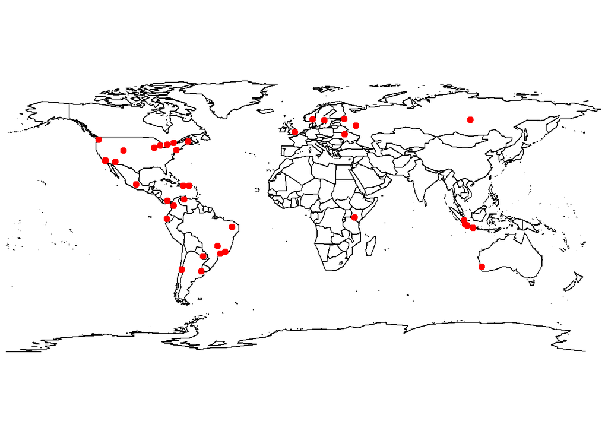

```r
library(maps)
map(mar=c(0,0,0,0))
points(tweets$lon, tweets$lat, col="red", pch=19, cex=1)
```

- Urządzenie z którego napisano tweety

Lista zawiera 30 najpopularniejszych urządzeń.

```r
library(stringi)
tweets$source <- stri_extract_all_regex(tweets$source, "(?<=>).+(?=<)", simplify = TRUE)
sort(table(tweets$source), decreasing = TRUE)[1:30]
```

```
##
##        Twitter for iPhone       Twitter for Android
##                      9070                      7582
##        Twitter Web Client                 TweetDeck
##                      3615                       827
##               twitterfeed          Twitter for iPad
##                       596                       571
##                     IFTTT                   dlvr.it
##                       502                       402
##                    Google               bestactor16
##                       397                       358
##                  Facebook           OscarsPredictor
##                       327                       234
##                 Hootsuite Twitter for Windows Phone
##                       213                       209
##           Mobile Web (M5)               Twittascope
##                       163                       155
##               SocialOomph           Mobile Web (M2)
##                       149                       138
##                 Instagram                 RoundTeam
##                       124                        93
##             WordPress.com          BestDirector2016
##                        92                        85
##             SocialToaster            Tweet Old Post
##                        84                        79
##                    Botize   TweetCaster for Android
##                        75                        67
##                    Buffer                 GrabInbox
##                        63                        63
##                Linkis.com                Mobile Web
##                        58                        53
```

- Język użytkownika

```r
sort(table(tweets$user_lang), decreasing = TRUE)
```

```
##
##      en      es      pt      fr      tr   en-gb      id      ru      it
##   16299    5883    2920     778     368     300     244     166     136
##      ja      th      ar      de   en-GB      nl      pl      ko      sv
##     134     106      85      84      80      62      59      54      31
##      ca   es-MX      el   zh-tw      uk      da   zh-cn      fi      no
##      14      13      10       8       7       6       6       4       4
##      ro      vi      bg      cs   en-AU   xx-lc      gl      he      hu
##       4       4       3       3       3       3       2       2       2
##   pt-PT      sr   zh-CN      eu      fa      lv     msa zh-Hans zh-Hant
##       2       2       2       1       1       1       1       1       1
##   zh-HK   zh-TW
##       1       1
```

- Najczęściej występujące słowa we wszystkich tweetach.

```r
words<-tweets$text
words<-stri_trans_tolower(words, locale = NULL)
words <- unlist(stri_extract_all_words(words))
head(sort(table(words), decreasing = TRUE), 20)
```

```
## words
##    https     t.co       rt    oscar      the       is        a      leo
##    20018    18916    18229    14435     8170     7902     7336     6252
##   oscars       de       an       in      you       to dicaprio     2016
##     5079     4804     4324     4012     3822     3528     3376     3279
## leonardo       do       of      won
##     3110     2989     2984     2857
```

- Najczęściej występujące słowa w polskich tweetach.

```r
tweets_pl <- tweets[tweets$lang == "pl",]$text
tweets_pl <- stri_trans_tolower(tweets_pl, locale = NULL)
words <- unlist(stri_extract_all_words(tweets_pl))
head(sort(table(words), decreasing = TRUE), 20)
```

```
## words
##   https    t.co   oscar      rt      to       z      na     nie    2016
##      19      19       8       6       6       6       4       4       3
##       3     ani     leo       w      że      62     amp      at    buff
##       3       3       3       3       3       2       2       2       2
##     bum contest
##       2       2
```

- Retweety

Ile w sumie retweetowano dalej pobrane tweety.

```r
sum(tweets$retweet_count)
```

```
## [1] 98379460
```

Tekst najczęściej retweetowanego tweeta, nazwa użytkownika oraz ilość retweetów.

```r
tweets[which.max(tweets$retweet_count),"text"]
```

```
## [1] "RT @TheEllenShow: If only Bradley's arm was longer. Best photo ever. #oscars http://t.co/C9U5NOtGap"
```

```r
tweets[which.max(tweets$retweet_count),"name"]
```

```
## [1] "felipe"
```

```r
max(tweets$retweet_count)
```

```
## [1] 3342219
```

Tekst najczęściej retweetowanego polskiego tweeta, nazwa użytkownika oraz ilość retweetów.

```r
tweets[which.max(tweets[tweets$lang=="pl",]$retweet_count),"text"]
```

```
## [1] "RT @TheFunnyTeens: Leo won an Oscar. Trump is a serious presidential candidate. Kanye is broke. Do what you want in 2016. Anything is possi…"
```

```r
tweets[which.max(tweets[tweets$lang=="pl",]$retweet_count),"name"]
```

```
## [1] "SaViWalker"
```

```r
max(tweets[tweets$lang=="pl",]$retweet_count)
```

```
## [1] 308
```

## 3. Wnioski

Temat oskarów jest bardzo popularny w Stanach Zjednoczonych. W Polsce nie cieszy się dużą popularnością. Osobą najczęściej pojawiającą się w tweetach jest Leonardo DiCaprio. Zaskoczeniem dla mnie był fakt, że najczęściej retweetowany polski tweet nie jest napisany po polsku.